# Updating the matrix inverse

Peter Ralph

May 15, 2015

Suppose that the covariance matrix we have at step $t$ is $A(t)$. We will be performing updates of the form $A(t+1) = A(t) + u(t) u(t)^T .$ Then we will want to, for a *fixed* vector $x$, calculate $r(t) = x^T A(t)^{-1} x .$

The [Sherman-Morrison formula](http://en.wikipedia.org/wiki/Sherman%E2%80%93Morrison_formula) says that $(A + uv^T)^{-1} = \mathcal{S}(A,u,v):= A^{-1} - \frac{ A^{-1} uv^T A^{-1} }{1 + v^T A^{-1} u} .$

Here’s an R function to do this (from Graham’s code):

```r
sherman <- function (A, u, v=u) {
    determ.update <- drop(1 + t(v) %*% A %*% u)
    # return(A - (A %*% u %*% t(v) %*% A)/determ.update)
    return(A - tcrossprod(A%*%u,crossprod(A,v))/determ.update)
}
```

Let’s check out how this does, by letting $S(0) = A(0)$ and then updating $S$ using the Sherman-Morrison formula. To get a reasonable $A(0)$, we’ll generate a spatiotemporal covariance matrix (see space-time-covariance.Rmd):

```r
n <- 10
A <- generate.covmat(n)
S <- ginv(A)
u <- rnorm(n)
Ap <- A+tcrossprod(u)  # next A
ginv.S <- ginv(Ap)
sherm.S <- sherman(S,u)
```

First, let’s make sure that `ginv` can invert it:

```r
range(ginv.S %*% Ap - diag(n))
```

```
## [1] -1.887379e-15  2.907397e-15
```

and, Sherman does just as well:

```r
range(sherm.S %*% Ap - diag(n))
```

```
## [1] -4.024558e-15  3.441691e-15
```

and, they agree:

```r
range(sherm.S-ginv.S)
```

```
## [1] -3.441691e-15  5.925815e-15
```

OK, now how do errors accumulate? Let’s do this for a bunch of time steps, and plot $\|A(t)^{-1} - S(t)\|$. For this, we want a *stationary* $A(t)$, or else its changing size will make comparison difficult; to this end, note that if $X$ and $Y$ are indepenent, ${\mathrm{var}}[X]=1$, and ${\mathrm{var}}[Y]=\sigma^2$, then ${\mathrm{var}}[\frac{X+Y}{\sqrt{1+\sigma^2}}] = 1$. $\begin{align*} u(t) &\sim N(0,I) \\ A(t+1) &= \frac{ A(t) + \epsilon u(t) u(t)^T }{ \sqrt{(1+\epsilon^2)} } \\ S(t+1) &= \sqrt{(1+\epsilon^2)} \mathcal{S}(A, \sqrt{\epsilon} u(t)) \end{align*}$

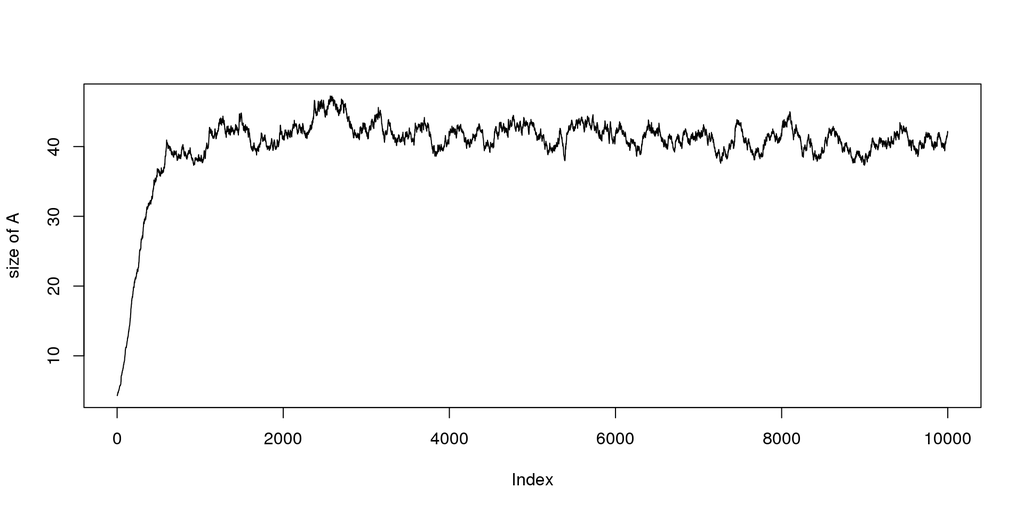

```r
eps <- 0.1
nsteps <- 1e4
S.diff <- numeric(nsteps)
sherm.check <- numeric(nsteps)
ginv.check <- numeric(nsteps)
A.size <- numeric(nsteps)
A <- generate.covmat(n)
S <- ginv(A)
for (t in seq_along(S.diff)) {
    u <- rnorm(n)
    A <- (A+eps*tcrossprod(u))/sqrt(1+eps^2)  # next A
    ginv.S <- ginv(A)
    S <- sherman(S,u*sqrt(eps)) * sqrt(1+eps^2)
    sherm.check[t] <- max(abs( S%*%A - diag(n) ))
    ginv.check[t] <- max(abs( ginv.S%*%A - diag(n) ))
    S.diff[t] <- sqrt( sum( (ginv.S-S)^2 ) )
    A.size[t] <- mean(A^2)
}
plot(A.size,ylab="size of A",type='l')
```

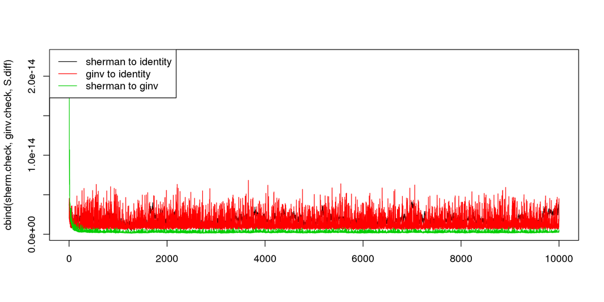

```r
matplot( cbind(sherm.check,ginv.check,S.diff), lty=1, col=1:3, type='l' )
legend("topleft",lty=1,col=1:3,legend=c("sherman to identity","ginv to identity","sherman to ginv"))
```

Well, that’s looking just fine.

# Almost singular matrices

What if $A$ is almost singular? Nothing good. This produces matrices that are almost singular:

```r
n <- 10
nit <- 1
while (nit < 100) {
    A <- expm( - crossprod(matrix(rnorm(n^2),nrow=n)) )  # get something posdef
    A[upper.tri(A)] <- t(A)[upper.tri(A)]  # make sure it's symmetric
    if (kappa(A)<1e15) { break; }
}
```

Directly inverting with `MASS::ginv` isn’t so hot:

```r
ginv(A) %*% A
```

[output not shown]

If $A=cov[X]$ is nearly singular, that means there is a vector $v$ such that $Av \approx 0$ and hence ${\mathrm{var}}[v^TX] \approx 0$. Now, what `ginv` does in dropping this vector is ignoring fluctuations in the direction of $v$, which is totally sensible, since we don’t have the numerical precision to measure them. So, `t(x) %*% ginv(A) %*% x` is effectively a pseudolikelihood for $X$; in principle, `x %*% solve(A,x)` would be better, with infinite-precision math.